# 1st Assignment of Reproducible Research Course

Nicolas Corneau-Tremblay

7/18/2017

## Preamble

This document is my submission for the first assignment of Coursera - Reproducible Research course. To complete this asignment, I use the following libraries :

```r
library(readr)
library(dplyr)
library(lubridate)
library(ggplot2)
```

## 1 : Code for reading in the dataset and/or processing the data

The data for this assignment is from a personal activity monitoring device and is available on Coursera website.

```r
activity <- read_csv("activity.csv")
head(activity)
```

```
## # A tibble: 6 x 3
##   steps       date interval
##   <int>     <date>    <int>
## 1    NA 2012-10-01        0
## 2    NA 2012-10-01        5
## 3    NA 2012-10-01       10
## 4    NA 2012-10-01       15
## 5    NA 2012-10-01       20
## 6    NA 2012-10-01       25
```

## 2 : Histogram of the total number of steps taken each day

Here is the histogram representing the total number of steps taken each day calculated on the entire sample. First, I create a new dataframe containing the total, the mean and the median number of steps taken for each day of the week. I then use this new dataframe to plot a histogram.

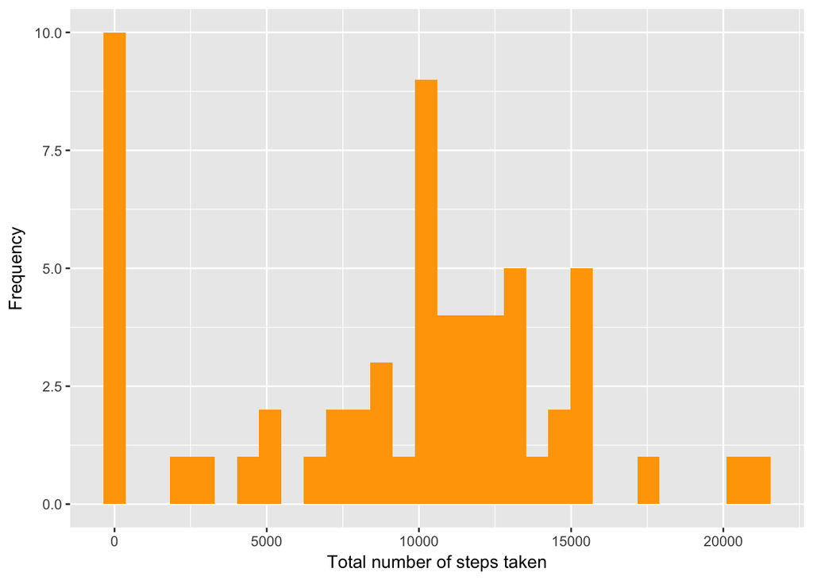

```r
day <- activity %>%
    group_by(date) %>%
    summarize(n.steps = sum(steps, na.rm = TRUE),
              mn.steps = mean(steps, na.rm = TRUE),
              md.steps = median(steps, na.rm = TRUE))


ggplot(day) +
    geom_histogram(aes(n.steps), fill = "orange") +
    xlab("Total number of steps taken") +
    ylab("Frequency")
```

## 3 : Mean and median number of steps taken each day

The **mean number of steps taken per day** is 9,354.23 and the **median number of steps taken per day** is 10,395.

## 4 : Time series plot of the average number of steps taken

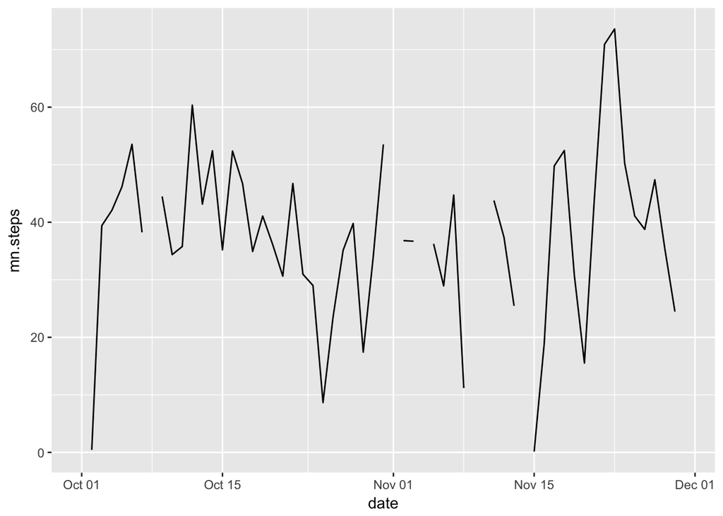

```r
ggplot(day) +
    geom_line(aes(date, mn.steps))
```

```r
inter <- activity %>%
    group_by(interval) %>%
    summarize(mn.steps = mean(steps, na.rm = TRUE)) %>%
    arrange(desc(mn.steps))
```

## 6 : Code to describe and show a strategy for imputing missing data

```r
imputed <- activity %>%
    arrange(date, interval) %>%
    group_by(date) %>%
    mutate(day.mean = mean(steps, na.rm = TRUE)) %>%
    ungroup() %>%
    mutate(all.mean = mean(steps, na.rm = TRUE))

imputed <- imputed %>%
    mutate(imp.val = as.integer(round(coalesce(day.mean, all.mean)))) %>%
    mutate(steps = coalesce(steps, imp.val))
```

After imputation, there is 0 missing value left in the new data set.

## 7 : Histogram of the total number of steps taken each day after missing values are imputed

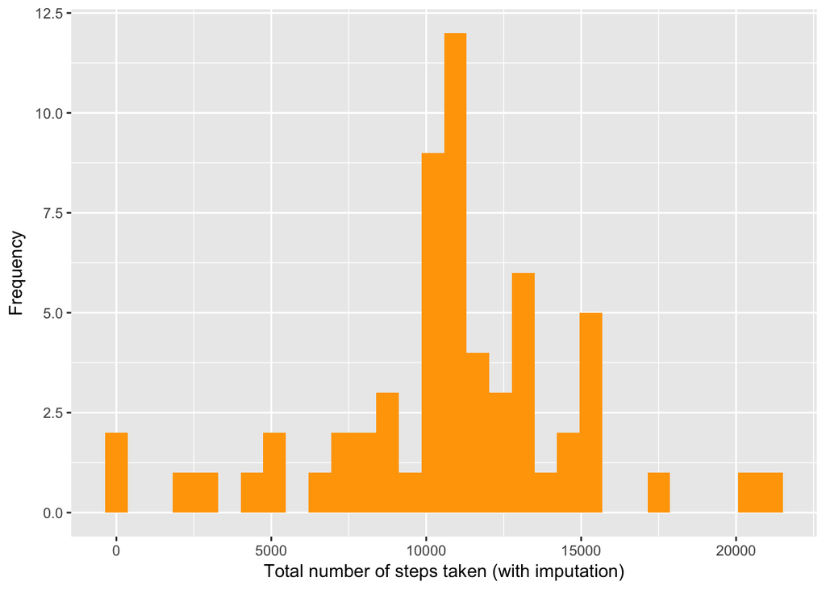

```r
day.imp <- imputed %>%
    group_by(date) %>%
    summarize(n.steps = sum(steps, na.rm = TRUE),
              mn.steps = mean(steps, na.rm = TRUE),
              md.steps = median(steps, na.rm = TRUE))


ggplot(day.imp) +
    geom_histogram(aes(n.steps), fill = "orange") +
    xlab("Total number of steps taken (with imputation)") +
    ylab("Frequency")
```

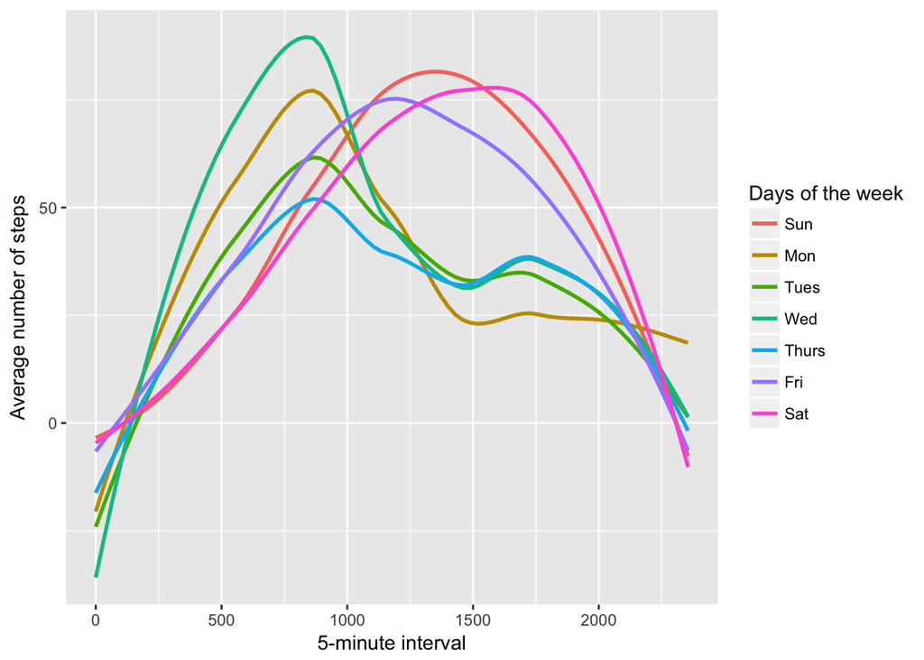

```r
week.day <- imputed %>%
    group_by(day = wday(date, label = TRUE, abbr = TRUE), interval) %>%
    summarize(mn.steps = mean(steps, na.rm = TRUE))

ggplot(week.day) +
    geom_smooth(aes(interval, mn.steps, group = day, color = day), se = FALSE) +
    labs(x = "5-minute interval",
         y = "Average number of steps",
         color = "Days of the week")
```

## 9 : All of the R code needed to reproduce the results (numbers, plots, etc.) in the report

The R code is available throughout the document.